# Cute3 Random Forest

Broto Bhattacharjee

June 22, 2018

# Clear Environment variables

# Set working directory

```r
setwd("C://Users//brbhatta//Desktop//INSOFE//Cute3")
```

# Read the train and test data

```r
original_data <- read.csv("train.csv")
test_data <- read.csv("test.csv")
```

- Meaning of the different attributes Attr1 net profit / total assets Attr2 total liabilities / total assets Attr3 working capital / total assets Attr4 current assets / short-term liabilities Attr5 [(cash + short-term securities + receivables - short-term liabilities) / (operating expenses - depreciation)] * 365 Attr6 retained earnings / total assets Attr7 EBIT / total assets Attr8 book value of equity / total liabilities Attr9 sales / total assets Attr10 equity / total assets Attr11 (gross profit + extraordinary items + financial expenses) / total assets Attr12 gross profit / short-term liabilities Attr13 (gross profit + depreciation) / sales Attr14 (gross profit + interest) / total assets Attr15 (total liabilities * 365) / (gross profit + depreciation) Attr16 (gross profit + depreciation) / total liabilities Attr17 total assets / total liabilities Attr18 gross profit / total assets Attr19 gross profit / sales Attr20 (inventory * 365) / sales Attr21 sales (n) / sales (n-1) Attr22 profit on operating activities / total assets Attr23 net profit / sales Attr24 gross profit (in 3 years) / total assets Attr25 (equity - share capital) / total assets Attr26 (net profit + depreciation) / total liabilities Attr27 profit on operating activities / financial expenses Attr28 working capital / fixed assets Attr29 logarithm of total assets Attr30 (total liabilities - cash) / sales Attr31 (gross profit + interest) / sales Attr32 (current liabilities * 365) / cost of products sold Attr33 operating expenses / short-term liabilities Attr34 operating expenses / total liabilities Attr35 profit on sales / total assets Attr36 total sales / total assets Attr37 (current assets - inventories) / long-term liabilities Attr38 constant capital / total assets Attr39 profit on sales / sales Attr40 (current assets - inventory - receivables) / short-term liabilities Attr41 total liabilities / ((profit on operating activities + depreciation) * (12/365)) Attr42 profit on operating activities / sales Attr43 rotation receivables + inventory turnover in days Attr44 (receivables * 365) / sales Attr45 net profit / inventory Attr46 (current assets - inventory) / short-term liabilities Attr47 (inventory * 365) / cost of products sold Attr48 EBITDA (profit on operating activities - depreciation) / total assets Attr49 EBITDA (profit on operating activities - depreciation) / sales Attr50 current assets / total liabilities Attr51 short-term liabilities / total assets Attr52 (short-term liabilities * 365) / cost of products sold) Attr53 equity / fixed assets Attr54 constant capital / fixed assets Attr55 working capital Attr56 (sales - cost of products sold) / sales Attr57 (current assets - inventory - short-term liabilities) / (sales - gross profit - depreciation) Attr58 total costs /total sales Attr59 long-term liabilities / equity Attr60 sales / inventory Attr61 sales / receivables Attr62 (short-term liabilities *365) / sales Attr63 sales / short-term liabilities Attr64 sales / fixed assets

# Load the required libraries

```r
library(DMwR)
library(caret)
```

```r
library(lattice)
library(ggplot2)
library(grid)
library(randomForest)
original_data <- original_data[,!colnames(original_data)%in%"ID"]
original_data$target <- as.factor(original_data$target)
```

## Understand the data

- Get the structure the data

```r
str(original_data)
```

```
## 'data.frame':    36553 obs. of  65 variables:
##  $ Attr1 : num  0.13537 0.00586 0.1106 0.06391 0.13168 ...
##  $ Attr2 : num  0.452 0.399 0.161 1.407 0.66 ...
##  $ Attr3 : num  0.312 0.198 0.479 -0.296 0.441 ...
##  $ Attr4 : num  2.047 1.939 7.571 0.529 2.71 ...
##  $ Attr5 : num  10.23 9.58 263.9 -46.29 -23.6 ...
##  $ Attr6 : num  0.168 0 0 -0.714 -0.2 ...
##  $ Attr7 : num  0.16763 0.00724 0.13836 0.07907 0.13191 ...
##  $ Attr8 : num  1.213 1.509 5.205 -0.331 0.514 ...
##  $ Attr9 : num  2.255 0.979 0.684 0.985 2.136 ...
##  $ Attr10: num  0.548 0.601 0.839 -0.465 0.34 ...
##  $ Attr11: num  0.1833 0.0295 0.1388 0.0791 0.1861 ...
##  $ Attr12: num  0.5632 0.0344 1.8983 0.1258 0.5112 ...
##  $ Attr13: num  0.0892 0.0364 0.2362 0.0303 0.1671 ...
##  $ Attr14: num  0.16763 0.00724 0.13836 0.07907 0.13191 ...
```

[output cut: 51 more lines]

- Get the summary the data

```r
summary(original_data)
```

```
##      Attr1                Attr2               Attr3
##  Min.   :-256.89000   Min.   :-430.8700   Min.   :-479.9600
##  1st Qu.:   0.00334   1st Qu.:   0.2696   1st Qu.:   0.0221
##  Median :   0.04960   Median :   0.4726   Median :   0.1975
##  Mean   :   0.05146   Mean   :   0.5777   Mean   :   0.1274
##  3rd Qu.:   0.13008   3rd Qu.:   0.6892   3rd Qu.:   0.4048
##  Max.   :  94.28000   Max.   : 480.9600   Max.   :  28.3360
##  NA's   :8            NA's   :8           NA's   :8
##      Attr4              Attr5               Attr6
##  Min.   :   -0.05   Min.   :-11903000   Min.   :-508.4100
##  1st Qu.:    1.05   1st Qu.:      -49   1st Qu.:   0.0000
##  Median :    1.57   Median :       -1   Median :   0.0000
##  Mean   :    6.84   Mean   :     -482   Mean   :  -0.0309
##  3rd Qu.:    2.79   3rd Qu.:       51   3rd Qu.:   0.0869
##  Max.   :53433.00   Max.   :  1034100   Max.   : 543.2500
##  NA's   :111        NA's   :76          NA's   :8
##      Attr7               Attr8              Attr9
##  Min.   :-517.4800   Min.   : -141.41   Min.   :  -3.496
##  1st Qu.:   0.0057   1st Qu.:    0.43   1st Qu.:   1.019
##  Median :   0.0595   Median :    1.07   Median :   1.200
##  Mean   :   0.1151   Mean   :   12.91   Mean   :   2.675
##  3rd Qu.:   0.1517   3rd Qu.:    2.61   3rd Qu.:   2.063
##  Max.   : 649.2300   Max.   :53432.00   Max.   :9742.300
##  NA's   :8           NA's   :79         NA's   :7
##      Attr10              Attr11              Attr12
##  Min.   :-479.9100   Min.   :-189.4500   Min.   :-6331.800
##  1st Qu.:   0.2948   1st Qu.:   0.0153   1st Qu.:    0.015
##  Median :   0.5056   Median :   0.0754   Median :    0.171
##  Mean   :   0.6496   Mean   :   0.1549   Mean   :    1.182
##  3rd Qu.:   0.7084   3rd Qu.:   0.1678   3rd Qu.:    0.586
##  Max.   :1099.5000   Max.   : 681.5400   Max.   : 8259.400
##  NA's   :8           NA's   :37          NA's   :111
##      Attr13              Attr14              Attr15
##  Min.   :-1317.600   Min.   :-517.4800   Min.   :-5611900
##  1st Qu.:    0.024   1st Qu.:   0.0057   1st Qu.:     220
##  Median :    0.068   Median :   0.0596   Median :     845
##  Mean   :    0.956   Mean   :   0.1152   Mean   :    2405
##  3rd Qu.:    0.135   3rd Qu.:   0.1517   3rd Qu.:    2222
##  Max.   :13315.000   Max.   : 649.2300   Max.   :10236000
##  NA's   :113         NA's   :8           NA's   :28
```

[output cut: 121 more lines]

```
##  Min.   :   -12.66   Min.   :  -14965   Min.   :   -0.368
##  1st Qu.:     4.51   1st Qu.:      42   1st Qu.:    3.099
##  Median :     6.63   Median :      71   Median :    5.079
##  Mean   :    17.68   Mean   :    1784   Mean   :    9.417
##  3rd Qu.:    10.38   3rd Qu.:     117   3rd Qu.:    8.607
##  Max.   :108000.00   Max.   :25016000   Max.   :23454.000
##  NA's   :86          NA's   :113        NA's   :111
##      Attr64          target
##  Min.   :    -3.73   0:34788
##  1st Qu.:     2.19   1: 1765
##  Median :     4.31
##  Mean   :    77.35
##  3rd Qu.:     9.79
##  Max.   :294770.00
##  NA's   :694
```

# Partition the data into train and validation

```r
set.seed(123)
index_id<- createDataPartition(original_data$target,p = 0.7,list = F)
pre_train <- original_data[index_id,]
pre_validation <- original_data[-index_id,]
```

# Count NA values

```r
sum(is.na(pre_train))
```

```
## [1] 24753
```

```r
sum(is.na(pre_validation))
```

```
## [1] 10434
```

# Use Knn imputation to impute the NA values in train data

```r
# Impute train data
imputed_train <- knnImputation(data = pre_train[,!colnames(pre_train)%in%"target"], k = 5, scale = T)
```

# Use Knn imputation to impute the NA values in validation data

```r
# Impute validation data
imputed_validation <- knnImputation(data = pre_validation[,!colnames(pre_validation)%in%"target"], k = 5, scale = T)
```

# Use Knn imputation to impute the NA values in test data

```r
# Impute test data
imputed_test <- knnImputation(data = test_data, k = 5, scale = T)
imputed_train$target <- pre_train$target
```

# Check the summary after Imputation

```r
sum(is.na(imputed_train))
```

```
## [1] 0
```

```r
sum(is.na(imputed_validation))
```

```
## [1] 0
```

# Create the prediction model using Random Forest

```r
model <- randomForest(target~., data=imputed_train, keep.forest = TRUE, ntree=100 )
print(model)
```

```
##
## Call:
##  randomForest(formula = target ~ ., data = imputed_train, keep.forest = TRUE,      ntree = 100)
##                Type of random forest: classification
##                      Number of trees: 100
## No. of variables tried at each split: 8
##
##         OOB estimate of  error rate: 4.82%
## Confusion matrix:
##       0  1 class.error
## 0 24256 96 0.003942181
## 1  1138 98 0.920711974
```

```r
model$importance
```

```
##        MeanDecreaseGini
## Attr1          26.16617
## Attr2          25.74802
## Attr3          33.85378
## Attr4          32.59651
## Attr5          46.93999
## Attr6          39.03855
## Attr7          28.44972
## Attr8          28.97354
## Attr9          39.50135
## Attr10         26.97952
## Attr11         28.96864
## Attr12         26.01096
## Attr13         33.67937
## Attr14         29.05793
## Attr15         36.78407
## Attr16         35.96786
## Attr17         26.36767
## Attr18         27.14523
## Attr19         27.50094
## Attr20         38.28056
## Attr21         37.19600
## Attr22         37.37397
## Attr23         27.61716
## Attr24         69.57310
## Attr25         36.95532
## Attr26         41.72021
## Attr27         58.31894
## Attr28         29.55901
## Attr29         39.78821
## Attr30         30.05240
## Attr31         27.96419
## Attr32         29.83267
## Attr33         32.15089
## Attr34         45.99418
## Attr35         48.91118
## Attr36         31.99817
## Attr37         34.98756
## Attr38         32.25546
## Attr39         44.60150
```

[output cut: 10 more lines]

```
## Attr50         30.43802
## Attr51         29.78676
## Attr52         28.00395
## Attr53         27.85881
## Attr54         31.93013
## Attr55         45.57181
## Attr56         56.14369
## Attr57         32.31543
## Attr58         63.51886
## Attr59         22.46128
## Attr60         41.64272
## Attr61         44.78738
## Attr62         26.92121
## Attr63         28.27634
## Attr64         30.09074
```

```r
round(model$importance,2)
```

```
##        MeanDecreaseGini
## Attr1             26.17
## Attr2             25.75
## Attr3             33.85
## Attr4             32.60
## Attr5             46.94
## Attr6             39.04
## Attr7             28.45
## Attr8             28.97
## Attr9             39.50
## Attr10            26.98
## Attr11            28.97
## Attr12            26.01
## Attr13            33.68
## Attr14            29.06
## Attr15            36.78
## Attr16            35.97
## Attr17            26.37
## Attr18            27.15
## Attr19            27.50
## Attr20            38.28
## Attr21            37.20
## Attr22            37.37
## Attr23            27.62
## Attr24            69.57
## Attr25            36.96
## Attr26            41.72
## Attr27            58.32
## Attr28            29.56
## Attr29            39.79
## Attr30            30.05
## Attr31            27.96
## Attr32            29.83
## Attr33            32.15
## Attr34            45.99
## Attr35            48.91
## Attr36            32.00
## Attr37            34.99
## Attr38            32.26
## Attr39            44.60
```

[output cut: 10 more lines]

```
## Attr50            30.44
## Attr51            29.79
## Attr52            28.00
## Attr53            27.86
## Attr54            31.93
## Attr55            45.57
## Attr56            56.14
## Attr57            32.32
## Attr58            63.52
## Attr59            22.46
## Attr60            41.64
## Attr61            44.79
## Attr62            26.92
## Attr63            28.28
## Attr64            30.09
```

# Check model importance plot

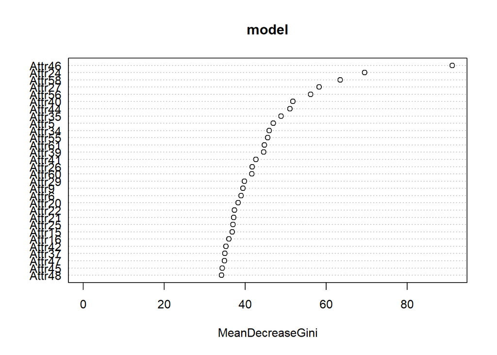

```r
rf_imp_attr <- data.frame(model$importance)
rf_imp_attr<- data.frame(row.names(rf_imp_attr),rf_imp_attr[,1])
colnames(rf_imp_attr)<- c("Attributes","Importance")
rf_imp_attr <- rf_imp_attr[order(rf_imp_attr$Importance,decreasing = TRUE),]
varImpPlot(model)
```

# Predict on train and check the accuracy

```r
pred_train_model <- predict(model,imputed_train[,setdiff(names(imputed_train),"target")],type = "response",norm.votes = TRUE)
cm_train <- table("actual"= imputed_train$target,"predicted"= pred_train_model)
print(cm_train)
```

```
##       predicted
## actual     0     1
##      0 24352     0
##      1     5  1231
```

```r
accu_train <- sum(diag(cm_train))/sum(cm_train)
accu_train
```

```
## [1] 0.9998046
```

# Check the accuracy on validation

```r
imputed_validation$target <- pre_validation$target
pred_validation_model <- predict(model,imputed_validation[,setdiff(names(imputed_validation),"target")],type = "response",norm.votes = TRUE)
cm_validation <- table("actual"= imputed_validation$target,"predicted"= pred_validation_model)
print(cm_train)
```

```
##       predicted
## actual     0     1
##      0 24352     0
##      1     5  1231
```

```r
accu_validation <- sum(diag(cm_validation))/sum(cm_validation)
accu_validation
```

```
## [1] 0.951482
```

# Take the important attributes and rebuild the model

```r
top_Imp_Attr <- as.character(rf_imp_attr$Attributes[1:19])
set.seed(365)
model_imp <- randomForest(target~.,data = imputed_train[,c(top_Imp_Attr,"target")],keep.forest = TRUE,ntree=100)
print(model_imp)
```

```
##
## Call:
##  randomForest(formula = target ~ ., data = imputed_train[, c(top_Imp_Attr,      "target")], keep.forest = TRUE, ntree = 100)
##                Type of random forest: classification
##                      Number of trees: 100
## No. of variables tried at each split: 4
##
##         OOB estimate of  error rate: 4.48%
## Confusion matrix:
##       0   1 class.error
## 0 24283  69 0.002833443
## 1  1077 159 0.871359223
```

```r
model_imp$importance
```

```
##        MeanDecreaseGini
## Attr46        171.62092
## Attr24        145.60603
## Attr58        131.33046
## Attr27        135.85633
## Attr56        133.29526
## Attr40        123.79984
## Attr44        113.97101
## Attr35        126.42463
## Attr5         139.19469
## Attr34        136.76170
## Attr55        114.60613
## Attr61        116.83585
## Attr39        121.34760
## Attr41        112.27788
## Attr26        117.77654
## Attr60        113.99207
## Attr29        102.14669
## Attr9         102.03112
## Attr6          89.16961
```

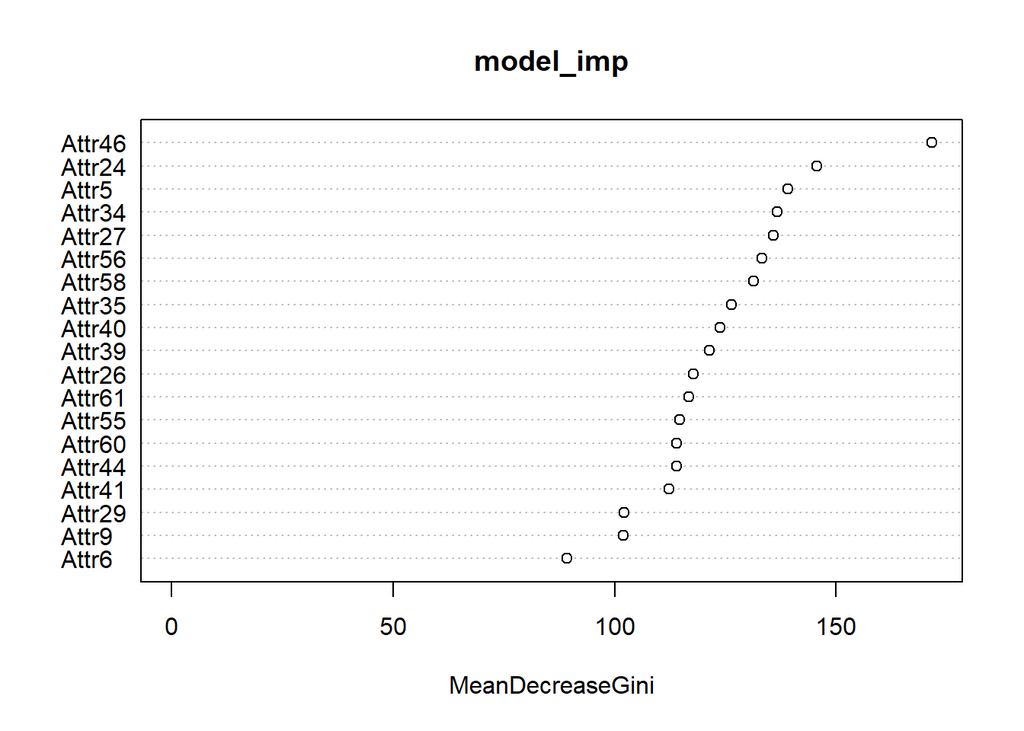

```r
varImpPlot(model_imp)
```

## Meaning of the important attributes based on domain knowledge

Attr46 (current assets - inventory) / short-term liabilities

# Predict on train using the second model

```r
pred_second_mod <- predict(model_imp,imputed_train[,top_Imp_Attr],type = "response",norm.votes = TRUE)
cm_second_train <- table("actual"= imputed_train$target,"predicted"=pred_second_mod)
accu_second_mode <- sum(diag(cm_second_train))/sum(cm_second_train)
print(accu_second_mode)
```

```
## [1] 0.9999609
```

# Predict on validation using the second model

```r
pred_second_valid_mode <- predict(model_imp,imputed_validation[,top_Imp_Attr],type = "response",norm.votes = TRUE)
cm_second_mode_valid <- table("actual"=imputed_validation$target,"prediction"=pred_second_valid_mode)
accu_second_mode_valid <- sum(diag(cm_second_mode_valid))/sum(cm_second_mode_valid)
accu_second_mode_valid
```

```
## [1] 0.9564067
```

```r
class(imputed_train$target)
```

```
## [1] "factor"
```

```
## mtry = 8  OOB error = 4.92%
## Searching left ...
## mtry = 6     OOB error = 4.95%
## -0.005555556 0.01
## Searching right ...
## mtry = 12    OOB error = 4.72%
## 0.04126984 0.01
## mtry = 18    OOB error = 4.64%
## 0.01655629 0.01
## mtry = 27    OOB error = 4.42%
## 0.04882155 0.01
## mtry = 40    OOB error = 4.34%
## 0.01769912 0.01
## mtry = 60    OOB error = 4.26%
## 0.01891892 0.01
## mtry = 64    OOB error = 4.25%
## 0.001836547 0.01
```

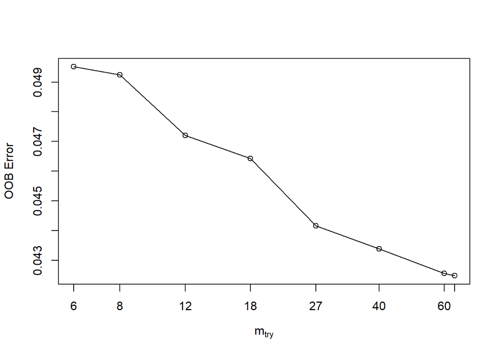

```r
mtry <- tuneRF(imputed_train[,!colnames(imputed_train)%in%"target"],imputed_train$target,ntreeTry = 100,stepFactor = 1.5,improve = 0.01,trace = TRUE,plot = TRUE)
```

```r
best.m <- mtry[mtry[,2]==min(mtry[,2]),1]
print(best.m)
```

```
## [1] 64
```

# Check with a different seed value

```r
set.seed(265)
rf <- randomForest(target~.,data = imputed_train,mtry=best.m,importance=TRUE,ntree=100)

print(rf)
```

```
##
## Call:
##  randomForest(formula = target ~ ., data = imputed_train, mtry = best.m,      importance = TRUE, ntree = 100)
##                Type of random forest: classification
##                      Number of trees: 100
## No. of variables tried at each split: 64
##
##         OOB estimate of  error rate: 4.24%
## Confusion matrix:
##       0   1 class.error
## 0 24263  89 0.003654731
## 1   996 240 0.805825243
```

```r
rf$importance
```

```
##                   0             1 MeanDecreaseAccuracy MeanDecreaseGini
## Attr1  0.0045836088 -2.889121e-03         0.0042183794         17.63744
## Attr2  0.0065511180 -3.391323e-03         0.0060727989         12.12040
## Attr3  0.0043110717 -2.354500e-03         0.0039902924         27.92745
## Attr4  0.0056748028 -7.511728e-03         0.0050409542         31.30856
## Attr5  0.0259484697 -4.405858e-03         0.0244809740        119.08618
## Attr6  0.0051537557  1.161678e-02         0.0054653210         49.99812
## Attr7  0.0061978332 -3.743884e-03         0.0057205193         12.04274
## Attr8  0.0042394367 -2.104931e-03         0.0039298414         15.25968
## Attr9  0.0059307712  1.395719e-03         0.0057115507         36.30281
## Attr10 0.0089917616 -6.576916e-03         0.0082368418         13.66138
## Attr11 0.0058178825 -4.233201e-03         0.0053346345         20.72539
## Attr12 0.0056880421 -3.975507e-03         0.0052249455         20.25497
## Attr13 0.0078346130 -9.853931e-04         0.0074047305         23.83732
## Attr14 0.0048721770 -2.015519e-03         0.0045437936         13.06429
## Attr15 0.0042395423  2.504988e-04         0.0040506529         39.95994
## Attr16 0.0092271818 -7.592506e-03         0.0084157538         20.05593
## Attr17 0.0061437975 -3.794613e-03         0.0056649258         13.55597
## Attr18 0.0059936206 -3.811319e-03         0.0055220878         11.24837
## Attr19 0.0036774750 -1.241966e-03         0.0034399495         13.22004
## Attr20 0.0090439737 -8.343929e-04         0.0085711500         32.36498
## Attr21 0.0009223753 -9.261021e-05         0.0008741455         55.32744
## Attr22 0.0169456573 -9.679032e-03         0.0156556272         26.37366
## Attr23 0.0026926143 -2.573029e-03         0.0024396526         14.56485
## Attr24 0.0200798190  1.960916e-02         0.0200603826         96.96877
## Attr25 0.0135548254 -8.542498e-03         0.0124864396         39.78902
## Attr26 0.0238048875 -5.664404e-03         0.0223739848         25.79724
## Attr27 0.0278264293 -2.689203e-02         0.0251899653         80.47783
## Attr28 0.0061554621 -4.143346e-03         0.0056551209         22.16623
## Attr29 0.0040430348 -1.864847e-03         0.0037576088         43.04019
## Attr30 0.0054253438 -5.013739e-03         0.0049246698         28.95109
## Attr31 0.0057772667 -3.496291e-03         0.0053270746         15.41942
## Attr32 0.0036335524 -2.349694e-03         0.0033459929         17.13521
## Attr33 0.0055226059 -7.484143e-03         0.0049004614         19.89986
## Attr34 0.0134093501  1.259266e-02         0.0133709177         81.40591
## Attr35 0.0189884506  5.736387e-03         0.0183477329         65.32378
## Attr36 0.0070033202 -6.499656e-03         0.0063519587         41.59754
## Attr37 0.0018521802 -1.669544e-03         0.0016852074         45.33651
## Attr38 0.0297270647 -7.459741e-03         0.0279308800         26.83328
## Attr39 0.0163142657  4.354200e-03         0.0157349482         57.53551
```

[output cut: 10 more lines]

```
## Attr50 0.0040924591 -4.631369e-03         0.0036710023         24.26497
## Attr51 0.0144243790 -5.453769e-03         0.0134687131         23.48145
## Attr52 0.0032119120 -2.801875e-03         0.0029242528         15.48299
## Attr53 0.0035672269 -3.711670e-03         0.0032185270         20.39133
## Attr54 0.0110863493 -4.503042e-03         0.0103298692         22.24048
## Attr55 0.0064913408 -3.615322e-05         0.0061724815         52.12035
## Attr56 0.0326250039 -6.092754e-02         0.0281097907         79.64048
## Attr57 0.0020684842  2.078781e-03         0.0020704019         38.51612
## Attr58 0.0171480315 -3.098142e-02         0.0148302762         53.36857
## Attr59 0.0010385405 -1.320017e-04         0.0009809621         29.17026
## Attr60 0.0062467046 -1.165928e-04         0.0059412396         35.01266
## Attr61 0.0153767093 -7.496073e-03         0.0142768330         51.22318
## Attr62 0.0051691018 -3.280918e-03         0.0047662953         16.25165
## Attr63 0.0028453409 -2.142917e-03         0.0026062705         16.22983
## Attr64 0.0035699665 -4.170353e-04         0.0033800788         28.44429
```

```r
round(rf$importance,2)
```

```
##           0     1 MeanDecreaseAccuracy MeanDecreaseGini
## Attr1  0.00  0.00                 0.00            17.64
## Attr2  0.01  0.00                 0.01            12.12
## Attr3  0.00  0.00                 0.00            27.93
## Attr4  0.01 -0.01                 0.01            31.31
## Attr5  0.03  0.00                 0.02           119.09
## Attr6  0.01  0.01                 0.01            50.00
## Attr7  0.01  0.00                 0.01            12.04
## Attr8  0.00  0.00                 0.00            15.26
## Attr9  0.01  0.00                 0.01            36.30
## Attr10 0.01 -0.01                 0.01            13.66
## Attr11 0.01  0.00                 0.01            20.73
## Attr12 0.01  0.00                 0.01            20.25
## Attr13 0.01  0.00                 0.01            23.84
## Attr14 0.00  0.00                 0.00            13.06
## Attr15 0.00  0.00                 0.00            39.96
## Attr16 0.01 -0.01                 0.01            20.06
## Attr17 0.01  0.00                 0.01            13.56
## Attr18 0.01  0.00                 0.01            11.25
## Attr19 0.00  0.00                 0.00            13.22
## Attr20 0.01  0.00                 0.01            32.36
## Attr21 0.00  0.00                 0.00            55.33
## Attr22 0.02 -0.01                 0.02            26.37
## Attr23 0.00  0.00                 0.00            14.56
## Attr24 0.02  0.02                 0.02            96.97
## Attr25 0.01 -0.01                 0.01            39.79
## Attr26 0.02 -0.01                 0.02            25.80
## Attr27 0.03 -0.03                 0.03            80.48
## Attr28 0.01  0.00                 0.01            22.17
## Attr29 0.00  0.00                 0.00            43.04
## Attr30 0.01 -0.01                 0.00            28.95
## Attr31 0.01  0.00                 0.01            15.42
## Attr32 0.00  0.00                 0.00            17.14
## Attr33 0.01 -0.01                 0.00            19.90
## Attr34 0.01  0.01                 0.01            81.41
## Attr35 0.02  0.01                 0.02            65.32
## Attr36 0.01 -0.01                 0.01            41.60
## Attr37 0.00  0.00                 0.00            45.34
## Attr38 0.03 -0.01                 0.03            26.83
## Attr39 0.02  0.00                 0.02            57.54
```

[output cut: 10 more lines]

```
## Attr50 0.00  0.00                 0.00            24.26
## Attr51 0.01 -0.01                 0.01            23.48
## Attr52 0.00  0.00                 0.00            15.48
## Attr53 0.00  0.00                 0.00            20.39
## Attr54 0.01  0.00                 0.01            22.24
## Attr55 0.01  0.00                 0.01            52.12
## Attr56 0.03 -0.06                 0.03            79.64
## Attr57 0.00  0.00                 0.00            38.52
## Attr58 0.02 -0.03                 0.01            53.37
## Attr59 0.00  0.00                 0.00            29.17
## Attr60 0.01  0.00                 0.01            35.01
## Attr61 0.02 -0.01                 0.01            51.22
## Attr62 0.01  0.00                 0.00            16.25
## Attr63 0.00  0.00                 0.00            16.23
## Attr64 0.00  0.00                 0.00            28.44
```

# Order the attributes according to their importance

```r
rf_imp_attr_final <- data.frame(rf$importance)
rf_imp_attr_final <- data.frame(row.names(rf_imp_attr_final),rf_imp_attr_final[,1])
colnames(rf_imp_attr_final)=c('Attributes','Importance')
rf_imp_attr_final= rf_imp_attr_final[order(rf_imp_attr_final$Importance, decreasing = TRUE),]
```

# Predict on train data

```r
pred_train_final <- predict(rf,imputed_train[,setdiff(names(imputed_train),"target")],type = "response",norm.votes = TRUE)
cm_train_final <- table("actual"=imputed_train$target,"predicted"=pred_train_final)
accu_train_final <- sum(diag(cm_train_final))/sum(cm_train_final)
accu_train_final
```

```
## [1] 0.9998828
```

# Predict on validation data

```r
pred_validation_final <- predict(rf, imputed_validation[,setdiff(names(imputed_validation),"target")],type = "response",norm.votes = TRUE)
cm_validation_final <- table("actual"=imputed_validation$target, "predicted"=pred_validation_final)
accu_validation_final <- sum(diag(cm_validation_final))/sum(cm_validation_final)
accu_validation_final
```

```
## [1] 0.9593251
```

# Predict on test data

```r
pred_test_final <- predict(rf, imputed_test, type = "response", norm.votes = TRUE)
print(pred_test_final)
```

```
##    1    2    3    4    5    6    7    8    9   10   11   12   13   14   15
##    0    0    0    0    0    0    0    0    0    0    0    0    0    0    0
##   16   17   18   19   20   21   22   23   24   25   26   27   28   29   30
##    0    0    0    0    0    0    0    0    0    0    0    0    0    0    0
##   31   32   33   34   35   36   37   38   39   40   41   42   43   44   45
##    0    0    0    0    0    0    0    0    0    0    0    0    0    0    0
##   46   47   48   49   50   51   52   53   54   55   56   57   58   59   60
##    0    0    0    0    0    0    0    0    0    0    0    0    0    0    0
##   61   62   63   64   65   66   67   68   69   70   71   72   73   74   75
##    0    0    0    0    0    0    0    0    0    0    0    0    0    0    0
##   76   77   78   79   80   81   82   83   84   85   86   87   88   89   90
##    0    0    0    0    0    0    0    0    0    0    0    0    0    0    0
##   91   92   93   94   95   96   97   98   99  100  101  102  103  104  105
##    0    0    0    0    0    0    0    0    0    0    0    0    0    0    0
##  106  107  108  109  110  111  112  113  114  115  116  117  118  119  120
```

[output cut: 848 more lines]

# Write the final prediction to broto_submission.csv

```r
imputed_test$target <- pred_test_final
imputed_test$ID <- test_data$ID
str(imputed_test)
```

```
## 'data.frame':    6451 obs. of  66 variables:
##  $ ID    : int  36554 36555 36556 36557 36558 36559 36560 36561 36562 36563 ...
##  $ Attr1 : num  0.20055 0.00902 0.12408 0.20393 -0.05462 ...
##  $ Attr2 : num  0.38 0.632 0.838 0.56 0.929 ...
##  $ Attr3 : num  0.3964 0.0537 0.142 0.1349 -0.0269 ...
##  $ Attr4 : num  2.047 1.126 1.169 1.241 0.943 ...
##  $ Attr5 : num  32.35 -37.84 -91.88 3.16 -87.72 ...
##  $ Attr6 : num  0.3882 0 0 0 -0.0546 ...
##  $ Attr7 : num  0.2498 0.0144 0.1533 0.2429 -0.0546 ...
##  $ Attr8 : num  1.3305 0.5822 0.1928 0.7845 0.0748 ...
##  $ Attr9 : num  1.139 1.333 2.116 2.271 0.923 ...
##  $ Attr10: num  0.5049 0.368 0.1616 0.4396 0.0695 ...
##  $ Attr11: num  0.2498 0.0432 0.1845 0.2499 -0.0546 ...
##  $ Attr12: num  0.6598 0.0339 0.1828 0.4335 -0.1164 ...
##  $ Attr13: num  0.1666 0.0389 0.0754 0.117 -0.0212 ...
```

[output cut: 52 more lines]

```r
index_value <- data.frame(index = imputed_test$ID,prediction = pred_test_final)
write.csv(index_value,"broto_submission.csv",na="")
```